# INFO521_HW6

## Course Information

INFO 521: Introduction to Machine Learning  
Instructor: Xuan Lu, College of Information Science

## Instructions

#### Objectives

This worksheet will assess your knowledge of basic commands in Python. Please review the lectures, suggested readings, and additional resources before starting the homework, as this document closely follows the provided materials.

#### Grading

Please note that grades are **NOT exclusively based on your final answers**. We will be grading the overall structure and logic of your code. Feel free to use as many lines as you need to answer each of the questions. I also highly recommend and strongly encourage adding comments (`#`) to your code. Comments will certainly improve the reproducibility and readability of your submission. Commenting your code is also good coding practice. **Specifically for the course, you’ll get better feedback if the TA is able to understand your code in detail.**

**Total score**: 100 points.

#### Submission

This homework is due on **April 7th (Tuesday, 11:59 pm AZ time)**. Please contact the instructor if you are (i) having issues opening the assignment, (ii) not understanding the questions, or (iii) having issues submitting your assignment. Note that late submissions are subject to a penalty (see late work policies in the syllabus).

- Please submit a single Jupyter Notebook file (this file). Answers to each question should be included in the relevant block of code (see below). Rename your file to "**lastname_Hw6.ipynb**" before submitting. If a given block of code is causing issues and you didn't manage to fix it, please add comments.

#### Time commitment

Please reach out if you’re taking more than ~18h to complete (1) this homework, (2) reading the book chapters, and (3) going over the lectures. I will be happy to provide accommodations if necessary. **Do not wait until the last minute to start working on this homework**. In most cases, working under pressure will certainly increase the time needed to answer each of these questions and the instructor and the TA might not be 100% available on Sundays to troubleshoot with you.

#### Looking for help?

First, please go over the relevant readings for this week. Second, if you’re still struggling with any of the questions, do some independent research (e.g. stackoverflow is a wonderful resource). Don’t forget that your classmates will also be working on the same questions - reach out for help (check under the Discussion forum for folks looking to interact with other students in this class or start your own thread). Finally, the TA is available to answer any questions during office hours and via email.

## Questions

#### Author:

Name: Yashvi Kommidi  
Affiliation: MSDS student at College of Information Science

### Conceptual

#### Question 1

Suppose that a curve $\hat{g}$ is computed to smoothly fit a set of `n` points using the following formula:

$$ \hat{g} = \arg\min_{g}(\sum_{i=1}^n (y_i - g(x_i))^2 + \lambda \int [g^{(m)} (x)]^2 dx ) $$ where $g^{(m)}$ represents the $m^{th}$ derivative of $g$ (and $g^{(0)} = g$). Provide a description (or sketch) of $\hat{g}$ in each of the following scenarios. **Again, don't forget that $m^{th}$ is related to the derivative of $g$**.

(a) $\lambda$ = $\infty$, $m = 0$.

> *Answer:* so according to the formula we know there are two parts first is the loss which tries to make the g(x) fit the data well and the next part is the penalty term which controls the behaviour or the g(x) which is scaled by λ

> in this case we have m =0 which means we are taking the 0th derivative of g , $g^{(0)} = g$

> which is equal to g so the penalty term becomes $ \lambda \int [g^{(0)} (x)]^2 dx $

> $ \lambda \int [g (x)]^2 dx $

> which means that we are penalising the size of the function itself. The other part is λ = ∞, here in this case the penalty term becomes infinitely large that is it dominates for any g(x) that is not zero and the data is totatlly ignored. Here the model will do anything to avoid that infinite penalty. The only way to make penalty equal to zero is to set $ \hat{g}(x)=0$ everywhere

$ ∫[g(x)]^2dx=0 $ only when $g(x) = 0 $

> We can say that in this case $\hat{g}$ is just a flat horizontal line at zero , which is the model ignores all the data and always predicts zero. This case is extreme underfitting that is maximum bias and zero variance.

(b) $\lambda$ = $\infty$, $m = 1$.

> *Answer:* here when m=1, it means we are considering the first derivative of g, so in this case the penalty term becomes $ λ∫[g′(x)]2dx $

which means that we are penalising how fast the g(x) is changing, that is penalising the slope of the function. in this case when we have λ = ∞ which means that the penalty term completely dominates and the data is ignored. And the way to make the penalty zero is $ λ∫[g′(x)]2dx=0 $

when g′(x) =0

that is g′(x) = 0 means that the function has zero slope everywhere that is g(x) must be a constant.

to know which is the constant, we know since the pnenalty is satisfied by any constant, the loss term now decides. And the constant that minimizes RSS is simply the mean of the observed y values that is $ĝ(x)=yˉ $

In this case the ĝ is a flat horizontal line at ȳ, here it is forced to be the mean of y value. Here the function cannot have any slope at all, This is also an extreme underfitting that is maximum bias and zero variance.

(c) $\lambda$ = $\infty$, $m = 2$.

> *Answer:* in this case when m=2, we will be considering the second derivative of g, then the penalty term in the formula becomes $λ∫[g′′(x)]2dx$

> this is nothing but the standard smoothing spline penalty, that is the second derivative measures the curvature of the function that is how much the slope is changing. And when the $λ = ∞$ means that the penalty completely dominates and the way to make the penalty terms zero is by $ [g′′(x)]2dx=0$ only when $g′′(x)=0$

> here g′′(x)=0 means that the function has zero curvature everywhere which means that the g(x) must be a straight line that is a linear function.

> as the penalty is satisfied by any straight line, the loss term now decides. That is the line that minimizes RSS is simply the ordinary least squares regression line g^(x)=β^0+β^1x

> here ĝ is the OLS regression line, the same line that is a linear regression one. We can say that this is still underfitting if the true relationship is non linear

(d) $\lambda$ = $\infty$, $m = 3$.

> *Answer:* here when m=3 we are taking the third derivative of g so the penalty term becomes $λ∫[g′′′(x)]2dx$

> here the third derivative measures how fast the curvature is changing and the other area where λ = ∞ mean that the penalty completely dominates that is the only way to make the penalty zeo is $∫[g′′′(x)]^2dx=0$ only when $g′′′(x)=0$

> here g′′′(x)=0 means that the function has zero change in curvature everywhere which means that the g(x) must be a quadratic function that is a degree 2 polynomial.

> Since the penalty is satisfied by any quadratic the term now decides. The quadratic that minimises RSS is $ĝ(x)$=β^0+β^1x+β^2x^2

> here ĝ is the best fitting quadratic that is degree 2 polynomial through the data which is the same as the polynomial regression with degree 2.

(e) $\lambda$ = 0, $m = 3$.

> *Answer:* here in this case λ = 0 which means when λ = 0 the penalty term completely dissapears then the formula becomes

$$ \hat{g} = \arg\min_{g}(\sum_{i=1}^n (y_i - g(x_i))^2 $$

so here we are now only minimizing the loss term (RSS), so there is no penalty controlling the behaviour of g(x) at all.

as there is no penalty g(x) is completely free to be as wiggy as it wants that is we know the smaller the λ, the more wiggly the function that is eventually interpolating y when λ=0

so here the function will pass through every single data point exactly making the RSS =0

ĝ(xi) = yi for all i.

here in this case ĝ is a wiggly interpolating function which passes through every datapoint exactly and condition of m=3 doesnt matter here because λ = 0 completely removes the penalty and the third derivative is never penelized at all . This is extreme overfitting which is zeo bias and maximum variance.

#### Question 2

For (1) step functions, (2) local regression, and (3) GAMs: provide one situation when using that particular model is advantageous. For instance, “GAMs is likely the preferred option when the question I’m interested in addressing involves…”.

> *Answer:* step functions are generally a preferred option when the case involves a discrete or categorical groupings in the data like distinct groups. We can consider a case which satisfies this such as when we are studying how is wage differs across distinct age groups like 20-30, 30-50 and over 50, in this case step functions usually makes sense because the pattern is generally local and group based. Step functions are also useful when we want to create easy to interpret interactions between variables like how a factor effects another factor like how age effects the wage facor before 2005 and after the year 2005. These are also useful when the pattern we are expecting is more sudden and abrupt rather than a smooth transition or a gradual change and step funtions are not idea when the true pattern is smooth because the wrong choice of knots can lead to misleading patterns.

> Local Regressions is preferred in the cases when the question involves the relationships that change gradually across the range of X, like depending on where the point in the data. for example, if the relationship between age and wage is not globally consistent but shifts smoothly depending on where you are in the data, the local regression handles this well because it fits separate weighted linear models at each point using only nearby observations like the relationship between age and wage might behave differently for young people when compared to the older people. Local regression handles this well because it looks at the nearby points to make a prediction at any given location like a sliding window moving across the data.

> GAMs are generally preferred when we have multiple predictors and each one has its own non linear relationship with the outcome. For example, if the wage depends on year, age and education all at once, but in different non linear ways, then usually GAMs let you model each predictor seperately and flexibly while still keeping the model interpretable and additive. In GAMs we can mix linear and non linear terms . Here we can look at each predictor effect individually through the plots like f1(year), f2(age) and f3(education) which makes the model easy to interpret.

#### Question 3

Briefly explain what spatial and temporal autocorrelation are? List one way in which GAMs could help to account for this (e.g. indicate the type of smooth function you would use or potential types of correlation structures).

> *Answer:* Temporal autocorrelation is nothing but when observations that are close or nearer in the time are more similar to each other than the observations that are far apart in the time. Like for example, the wage of a person this year is mostly similar to their wage last year, but can be different when compared to the wage after 5 years or before 5 years data. The data points are not independent that is they are correlated through the time. when it comes to spatial autocorrelation, this happens when the observations that are close in space are more similar to each other than the observations that are far apart. Like for example we can consider a case like house prices in nearby neighborhoods tend to have a similar costs rather than houses which are in the both ends of the cities, or comparing houses which are in different cities. Here also the data points are not independent, they are correlated through the location.

> GAMs can account for both the autocorrelations, in the case of temporal autocorrelation, we can add a smooth function of time like f(time as a predictor in the GAM, which captures the gradual trend over time and soaks up the temporal correlation in the data, and when it comes to spatial autocorrelation, we can use a bivariate smooth function of the location like f(latitude, longitude) which models the spatial pattern across two dimensions simultaneously, And also we can say that the GAMs can incorporate correlation structures like AR1 in time series directly into the model to explicitly account for the fact that nearby observations are not independent.

#### Question 4

Briefly define the following types of smooth functions in `pygam` and list at least two relevant potential uses.

a) `s()`

> *Answer:* s() stands for the spline smooth which is nothing but it fits a smooth curved relationship between a single predictor and the outcome using splines. It is most commonly used smooth function in the pygam. It actually captures the nonlinear but gradually changing relationships in a flexible way. with the help of s() we can draw a smooth flexible curve through the data for one predictor at a time which is not a straight line not too wiggly just its a smooth fit that follows the general trend of the data. s() can generally be use in cases like modelling age and wage like if we want to model how wage changes with age in a nonlinear way like rising in the early career, peaking the middle age and declining later and the elderly age, s(age) would help us to capture this smooth curved pattern which is generally much better than a straight line. And also in the case of modelling temperature over the time, like across the different days of the year, like gradually warming in spring, then how it is in summer and cooling in the fall, the function s(time) helps us to capture the smooth seasonal trend naturally.

b) `te()`

> *Answer:* the function te() stands for tensor product smooth function which generally fits a smooth relationship between two or more predictors jointly which means it usually models how the combination of multiple predictors together effects the outcome. te() handle more than one predictor that is it captures the interaction between two or more predictors in a smooth way. te() feels like an extension to s() as it is used for two or more predictors at the same time. Here instead of drawing a curve through one variable, it draws a smooth surface across two variables together. This is generally useful when the effect of one predictor depends on the value of another predictor.

> te() is generally used in cases like modelling the spatial data like how house prices vary across the city using te(latitude, longitude), which would capture the smooth spatial pattern across two dimensions simultaneously. and in the other case is modelling the temperature across time and altitude like how temperature changes depending on both the time of the year and the altitude of a location together like te(time, altitude) would capture how these two variables interact to affect temperature.

#### Question 5

Consider two curves $\hat{g}1$ and $\hat{g}2$, defined by

$$ \hat{g}1 = \arg\min_{g}(\sum_{i=1}^n (y_i - g(x_i))^2 + \lambda \int [g^{(3)} (x)]^2 dx ) $$

$$ \hat{g}2 = \arg\min_{g}(\sum_{i=1}^n (y_i - g(x_i))^2 + \lambda \int [g^{(4)} (x)]^2 dx ) $$

where $g^{(m)}$ represents the $m^{th}$ derivative of $g$. Now, answer the following questions (and include a brief explanation):

a) As $\lambda \rightarrow \infty$, will $\hat{g}1$ or $\hat{g}2$ have smaller training RSS?

> *Answer:* We know that as λ → ∞ the penalty completely dominates and forces each function to become a polynomial, that is ĝ1 has m=3 which means that third derivative forced to zero that becomes a degree2 that is quadratic polynomial and ĝ2 has m = 4 that is fourth derivative forced to zero that it becomes a degree 3 that is a cubic polynomial. We can say that ĝ2 will have smaller training RSS because ĝ2 is forced into a cubic polynomial which is more flexible than the quadratic that ĝ1 is forced into. A degree 3 cubic polynomial has one extra term which is $βpower3xpower3$ which gives it more freedom to fit the training data better, so because of this ĝ2 achieving a lower training RSS than ĝ1. We know that the cubic curve has more wiggle room than a quadratic which means it has more fliexibility that it has better fit to training data and also lower training RSS. We can say that ĝ2 is simply less restricted than ĝ1 so it will always fit the training data

b) As $\lambda \rightarrow \infty$, will $\hat{g}1$ or $\hat{g}2$ have smaller test RSS?

> *Answer:* in this question it is asking $\hat{g}1$ or $\hat{g}2$ will have smaller test RSS, generally RSS depends on how well the model generalises to new data not just how well it fits the training data.

> firstly $\hat{g}1$ is forced into a quadratic polynomial that is degree 2 and $\hat{g}2$ is forced into a cubic degree 3 polynomial. if we want to which is gonna have smaller test RSS, it all depends on the true relationship in the data, If the true relationship is quadratic then $\hat{g}1$ will have smaller test RSS because the extra flexibility of $\hat{g}2$ is unnecessary and may overfit. On the other side, if the true relationship is cubic then $\hat{g}2$ will have smaller test RSS because it can capture the true pattern in a better way. At last if the true relationship is simpler than both, then $\hat{g}1$ will have smaller test RSS because it is the simpler model. We can also say that in the case of test RSS, more flexibility is not always better because it depends on whether the extra flexibility actually matches the true underlying pattern in the data.

c) For $\lambda= 0$, will $\hat{g}1$ or $\hat{g}2$ have smaller training RSS?

> *Answer:* in this question we want to know which one will be having smaller training RSS when the λ = 0, so here when the λ = 0 the penalty term completely disappears for both the $\hat{g}1$ and $\hat{g}2$. Then the formula becomes

$$\hat{g} = \arg\min_{g}(\sum_{i=1}^n (y_i - g(x_i))^2 )$$

> here both the models are only minimizing the loss term(RSS) that is there no penalty controlling the behavior of either function at all. In this case ĝ1 and ĝ2 will have the same training RSS. Since applying λ = 0, this will automatically removes the penalty term completely from both the models, this makes both the functions free to be as wiggly as they want and also will able to interpolate through every single data point exactly making RSS = 0 for both. ĝ1(xi)=ĝ2(xi)=yi for all i.

> we know the main difference between ĝ1 and ĝ2 is their penalty terms that is one penalizes the 3rd derivative and the other one penalises the 4th derivative but as we have condition of λ = 0, this has made that neither penalty matters, so both the models behave identically and achieve the same training RSS of zero.

## Applied

#### Question 6

This question relates to the `College` data set.

a) Split the data into a training set and a test set (70:30). Using out-of-state tuition as the response and the other variables as the predictors, perform *forward* stepwise selection on the training set in order to identify a satisfactory model that uses just a subset of the predictors.

```python
#importing libraries
import pandas as pd
import numpy as np
from sklearn.model_selection import train_test_split, cross_val_score
from sklearn.linear_model import LinearRegression
from sklearn.metrics import mean_squared_error

#loading the data and preparing the data
df = pd.read_csv('College.csv', index_col=0)
df['Private'] = (df['Private'] == 'Yes').astype(int)

X = df.drop('Outstate', axis=1)
y = df['Outstate']

#performing the 70:30 split for the data
X_train, X_test, y_train, y_test = train_test_split(X, y, test_size=0.3, random_state=42)

# doing the forward stepwise selection
remaining, selected, results = list(X.columns), [], []

while remaining:
    best_rss, best_feat = np.inf, None
    for feat in remaining:
        model = LinearRegression().fit(X_train[selected + [feat]], y_train)
        rss = mean_squared_error(y_train, model.predict(X_train[selected + [feat]])) * len(y_train)
        if rss < best_rss:
            best_rss, best_feat = rss, feat
#adding the best predictor to selected and remove from remaining
    selected.append(best_feat)
    remaining.remove(best_feat)
    results.append((len(selected), selected.copy(), best_rss))

#picking the best model using 5-fold cross validation
best_cv, best_feats = np.inf, None
for _, feats, _ in results:
    cv = -cross_val_score(LinearRegression(), X_train[feats], y_train,
                          cv=5, scoring='neg_mean_squared_error').mean()
    if cv < best_cv:
        best_cv, best_feats = cv, feats

#printing the best features and the CV MSE
print(f"Best features are :({len(best_feats)}): {best_feats}")
print(f"CV MSE: {best_cv:.2f}")
```

```
Best features are :(13): ['Expend', 'Private', 'Room.Board', 'perc.alumni', 'PhD', 'Grad.Rate', 'Terminal', 'Top25perc', 'S.F.Ratio', 'Accept', 'Apps', 'Enroll', 'P.Undergrad']
CV MSE: 4097582.04
```

b) Fit a GAM on the training data, using out-of-state tuition as the response and the features selected in the previous step as the predictors. Plot the results, and briefly explain your findings.

[output not shown]

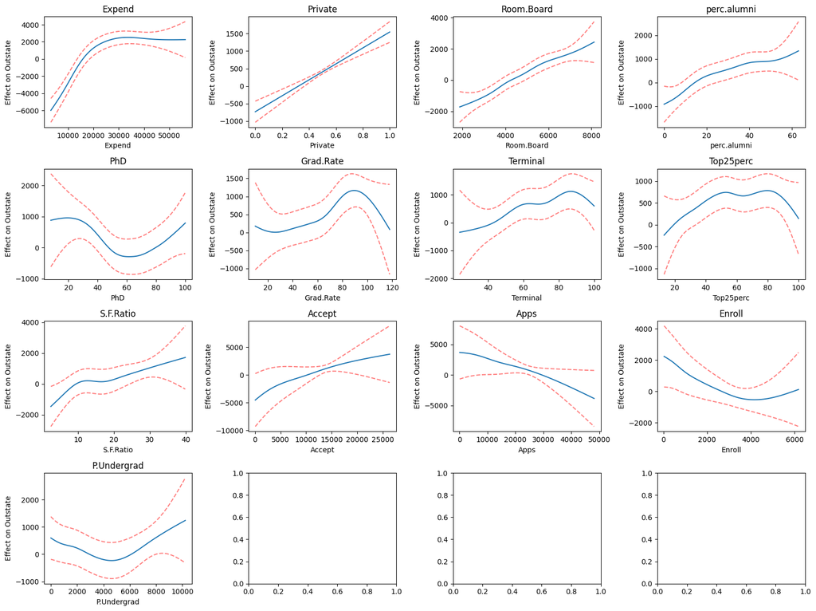

```python
from pygam import LinearGAM, s
import matplotlib.pyplot as plt

#fitting the GAM model using the selected features
X_train_gam = X_train[best_feats].values

# building the GAM with a spline for each predictor
gam = LinearGAM(s(0) + s(1) + s(2) + s(3) + s(4) + s(5) + s(6) +
                s(7) + s(8) + s(9) + s(10) + s(11) + s(12))

#using the gridsearch to automatically find the best smoothing parameter lambda
gam.gridsearch(X_train_gam, y_train)

#plotting the results we get
fig, axes = plt.subplots(4, 4, figsize=(16, 12))
axes = axes.flatten()

#looping through each of the features and also plotting its partial dependence
for i, feat in enumerate(best_feats):
    XX = gam.generate_X_grid(term=i)
    axes[i].plot(XX[:, i], gam.partial_dependence(term=i, X=XX))
    axes[i].plot(XX[:, i], gam.partial_dependence(term=i, X=XX, width=0.95)[1],
                 c='r', ls='--', alpha=0.5)
    axes[i].set_title(feat)
    axes[i].set_xlabel(feat)
    axes[i].set_ylabel('Effect on Outstate')

plt.tight_layout()
plt.show()
```

> *Answer:* we got the partial dependence plots and from these we can see plots with strong positive effects, non linear and mixed effects and also weak and uncertain effects.

> Coming to the plots with strong positive effects, in expend plot, we can see that the out of state tuition rises sharply as expenditure increases up to around $30000 and then levels off which is clear nonlinear relationship, in the private plot, we can see the strong positive effect that is the private colleges charge significantly more tuition than public ones. In the Room.Board plot, we can observe a consistent positive relationship, that is higher room and board costs means higher tuitions. and atlast in the perc.alumni graph we can see a positive effect that is the colleges with more alumni donors tend to have higher tuitions.

c) For which variables, if any, is there evidence of a non-linear relationship with the response?

```python
#checking for non-linear relationships using the GAM summary
# conditions are : EDoF > 1 means non-linear, p-value < 0.05 means statistically significant
print(gam.summary())
```

```
LinearGAM
=============================================== ==========================================================
Distribution:                        NormalDist Effective DoF:                                     43.8554
Link Function:                     IdentityLink Log Likelihood:                                 -8626.4686
Number of Samples:                          543 AIC:                                             17342.648
                                                AICc:                                           17350.9227
                                                GCV:                                          3698770.6436
                                                Scale:                                        3165254.0513
                                                Pseudo R-Squared:                                   0.8211
==========================================================================================================
Feature Function                  Lambda               Rank         EDoF         P > x        Sig. Code
================================= ==================== ============ ============ ============ ============
s(0)                              [63.0957]            20           5.7          1.11e-16     ***
s(1)                              [63.0957]            20           3.0          1.18e-12     ***
s(2)                              [63.0957]            20           5.2          1.87e-06     ***
s(3)                              [63.0957]            20           4.6          4.91e-02     *
s(4)                              [63.0957]            20           4.8          7.66e-02     .
s(5)                              [63.0957]            20           4.1          2.52e-03     **
s(6)                              [63.0957]            20           3.3          9.15e-02     .
s(7)                              [63.0957]            20           3.9          2.37e-01
s(8)                              [63.0957]            20           2.0          3.79e-02     *
s(9)                              [63.0957]            20           3.6          7.48e-05     ***
s(10)                             [63.0957]            20           0.8          8.76e-03     **
s(11)                             [63.0957]            20           1.2          9.06e-03     **
s(12)                             [63.0957]            20           1.6          2.55e-01
intercept                                              1            0.0          1.11e-16     ***
==========================================================================================================
Significance codes:  0 '***' 0.001 '**' 0.01 '*' 0.05 '.' 0.1 ' ' 1

WARNING: Fitting splines and a linear function to a feature introduces a model identifiability problem
         which can cause p-values to appear significant when they are not.

WARNING: p-values calculated in this manner behave correctly for un-penalized models or models with
         known smoothing parameters, but when smoothing parameters have been estimated, the p-values
         are typically lower than they should be, meaning that the tests reject the null too readily.
None
```

> *Answer:* comparing the conditions like when EDoF >1 its a non linear relationship and when EDoF≈ 1 then its a roughly linear relationship. and from the summary we cansay that Expend, Room.Board, Private, Grad.Rate and Accept plots have EDoF greater than 1 and also they have significant p values like Expend has 5.7 EDoF, Room.Board has 5.2 EDoF, PhD has 4.8 EDoF and so on. And on the other side, we have Apps which has 0.8 EDoF and Enroll has 1.2 EDoF which are closest to the linear. We can also observe from the summary that the p values may be lower than they should be so these results which we got should be interpreted with caution.

#### Question 7

Answer the questions below using the `HW6_data` dataset:

a) Inspect if there is any temporal or spatial trend in the response variable `richness` with plots.

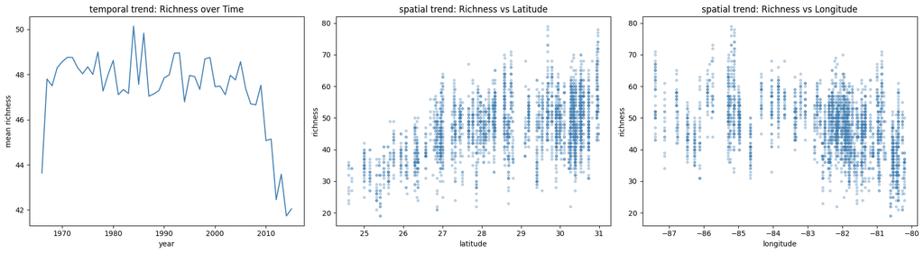

```python
#importing libraries
import pandas as pd
import matplotlib.pyplot as plt

#loading the HW6 data
df = pd.read_csv('HW6_data', sep='\t', index_col=0)

fig, axes = plt.subplots(1, 3, figsize=(18, 5))

#code for the temporal trend that is richness over years
yearly = df.groupby('Year')['richness'].mean()
axes[0].plot(yearly.index, yearly.values, color='steelblue')
axes[0].set_xlabel('year')
axes[0].set_ylabel('mean richness')
axes[0].set_title('temporal trend: Richness over Time')

# code for the spatial trend that is richness vs latitude
axes[1].scatter(df['Latitude'], df['richness'], alpha=0.3, color='steelblue', s=10)
axes[1].set_xlabel('latitude')
axes[1].set_ylabel('richness')
axes[1].set_title('spatial trend: Richness vs Latitude')

#code for the spatial trend that is between richness and longitude
axes[2].scatter(df['Longitude'], df['richness'], alpha=0.3, color='steelblue', s=10)
axes[2].set_xlabel('longitude')
axes[2].set_ylabel('richness')
axes[2].set_title('spatial trend: Richness vs Longitude')

#printing the plots
plt.tight_layout()
plt.show()
```

b) Now, fit a Poisson GAM that predicts richness using year and location. Note that location is actually two features: `Longitude` and `Latitude`. Name this model `M1`. Plot the model, get the `summary` of `M1`, and answer: Is there evidence for effects of location and year?

[output not shown]

```
PoissonGAM
=============================================== ==========================================================
Distribution:                       PoissonDist Effective DoF:                                     74.2111
Link Function:                          LogLink Log Likelihood:                                  -9186.981
Number of Samples:                         2824 AIC:                                            18522.3841
                                                AICc:                                           18526.5562
                                                UBRE:                                               2.9056
                                                Scale:                                                 1.0
                                                Pseudo R-Squared:                                   0.5337
==========================================================================================================
Feature Function                  Lambda               Rank         EDoF         P > x        Sig. Code
================================= ==================== ============ ============ ============ ============
s(0)                              [0.001]              20           20.0         0.00e+00     ***
te(1, 2)                          [0.001 0.001]        100          54.2         0.00e+00     ***
intercept                                              1            0.0          2.73e-01
==========================================================================================================
Significance codes:  0 '***' 0.001 '**' 0.01 '*' 0.05 '.' 0.1 ' ' 1

WARNING: Fitting splines and a linear function to a feature introduces a model identifiability problem
         which can cause p-values to appear significant when they are not.

WARNING: p-values calculated in this manner behave correctly for un-penalized models or models with
         known smoothing parameters, but when smoothing parameters have been estimated, the p-values
         are typically lower than they should be, meaning that the tests reject the null too readily.
None
```

[figure not shown]

```python
from pygam import PoissonGAM, s, te
import matplotlib.pyplot as plt

#loading the data
df = pd.read_csv('HW6_data', sep='\t', index_col=0)
X = df[['Year', 'Latitude', 'Longitude']].values
y = df['richness'].values

#then fitting the Poisson GAM M1 that is s() for year, te() for location jointly
M1 = PoissonGAM(s(0) + te(1, 2))
M1.gridsearch(X, y)

#printing the summary of M1
print(M1.summary())

#plotting the results of M1
fig, axes = plt.subplots(1, 2, figsize=(12, 5))

#generating the plots
XX = M1.generate_X_grid(term=0)
axes[0].plot(XX[:, 0], M1.partial_dependence(term=0, X=XX))
axes[0].plot(XX[:, 0], M1.partial_dependence(term=0, X=XX, width=0.95)[1], c='r', ls='--', alpha=0.5)
axes[0].set_title('effect of year')
axes[0].set_xlabel('year')

XX = M1.generate_X_grid(term=1)
axes[1].plot(XX[:, 1], M1.partial_dependence(term=1, X=XX))
axes[1].plot(XX[:, 1], M1.partial_dependence(term=1, X=XX, width=0.95)[1], c='r', ls='--', alpha=0.5)
axes[1].set_title('effect of location')
axes[1].set_xlabel('latitude/longitude')

plt.tight_layout()
plt.show()
```

c) Now, fit another Poisson GAM model with the same structure as in `M1` but also consider the interactions between location (`longitude`, `latitude`) and `year`. Name this model `M2`.

```python
#fitting the poisson GAM M2 with the interactions between location and year
M2 = PoissonGAM(te(0, 1, 2))
M2.gridsearch(X, y)

#printing the summary of M2
print(M2.summary())
```

[output not shown]

```
PoissonGAM
=============================================== ==========================================================
Distribution:                       PoissonDist Effective DoF:                                    271.5149
Link Function:                          LogLink Log Likelihood:                                 -8878.8673
Number of Samples:                         2824 AIC:                                            18300.7644
                                                AICc:                                           18359.2136
                                                UBRE:                                                2.883
                                                Scale:                                                 1.0
                                                Pseudo R-Squared:                                    0.656
==========================================================================================================
Feature Function                  Lambda               Rank         EDoF         P > x        Sig. Code
================================= ==================== ============ ============ ============ ============
te(0, 1, 2)                       [0.0158 0.0158 0.015 1000         271.5        0.00e+00     ***
intercept                                              1            0.0          0.00e+00     ***
==========================================================================================================
Significance codes:  0 '***' 0.001 '**' 0.01 '*' 0.05 '.' 0.1 ' ' 1

WARNING: Fitting splines and a linear function to a feature introduces a model identifiability problem
         which can cause p-values to appear significant when they are not.

WARNING: p-values calculated in this manner behave correctly for un-penalized models or models with
         known smoothing parameters, but when smoothing parameters have been estimated, the p-values
         are typically lower than they should be, meaning that the tests reject the null too readily.
None
```

d) Use an ANOVA to compare `M1` and `M2`. Which model should we select based on this test?

```python
import scipy.stats as stats

# ANOVA to compare M1 and M2
deviance_diff = M1.statistics_['deviance'] - M2.statistics_['deviance']
df_diff = M2.statistics_['edof'] - M1.statistics_['edof']
p_value = stats.chi2.sf(deviance_diff, df_diff)

print(f"M1 Deviance: {M1.statistics_['deviance']:.4f}")
print(f"M2 Deviance: {M2.statistics_['deviance']:.4f}")
print(f"Deviance Difference: {deviance_diff:.4f}")
print(f"DF Difference: {df_diff:.4f}")
print(f"P-value: {p_value:.6f}")
```

```
M1 Deviance: 2349.6805
M2 Deviance: 1733.4532
Deviance Difference: 616.2273
DF Difference: 197.3038
P-value: 0.000000
```

> By looking at the results we can say that we should select M2, here the p value is 0.000000 which is less than the 0.05 which. means that M2 is significantly better than M1, The deviance also dropped from 2349.68 in M1 to 1733.45 in M2 which is a difference of 616.23 which infact is a large improvement. So this generally tells us that including the interactions between the year and location, will significantly improves the model fit.

e) Finally, can you come up with a simple approach to examine which of the features (`latitude`, `longitude`, or `year`) have a larger impact on the response (`richness`) using GAMs?

```python
#fitting the individual GAMs for each feature to compare their impact
features = {'Year': 0, 'Latitude': 1, 'Longitude': 2}

for name, idx in features.items():
    # then fitting a simple GAM with just one feature at a time
    gam = PoissonGAM(s(0))
    gam.gridsearch(X[:, idx].reshape(-1, 1), y)
    r2 = gam.statistics_['pseudo_r2']['explained_deviance']
    print(f"{name}: Pseudo R² = {r2:.4f}")
```

[output not shown]

```
Year: Pseudo R² = 0.0353
Latitude: Pseudo R² = 0.3403
Longitude: Pseudo R² = 0.2854
```

looking at the results we can say that latitude has the largest impact on richness with Pseudo R² of 0.3403 which means that it alone explains about 34% of the variance in richness. On the other hand longitude is second with a Pseudo R² of 0.2854 which explains about 28% of the variance and the year has the smallest individual impact with a Pseudo R² of only 0.0353 which explains only about 3.5% of the variance on its own. We can say that the location expecially latitude drives richness the most.